# CDISC Pilot Study: SDTM to ADaM to TLFs, Independently Validated

Xanomeline transdermal patch in mild-to-moderate Alzheimer’s disease (CDISCPILOT01)

Author

Zi-Jie Liu

## Summary

- Derived four ADaM datasets (ADSL, ADQSADAS, ADAE, ADTTE) from raw SDTM with the pharmaverse `admiral` package.
- Independent QC against the CDISC reference ADaM: **29 variables, 13,400 values compared, 29 / 29 variables matched 100%.**
- The primary analysis reproduces the published Table 14-3.01 of the FDA R Submission Pilot: dose-response p = 0.245 (published 0.245); high dose vs placebo p = 0.233 (published 0.233).
- An MMRM on observed data (no LOCF) leads to the same conclusion: no significant cognitive benefit at Week 24.
- Dermatologic adverse events occur much earlier on xanomeline (Cox HR 5.28 for high dose vs placebo, log-rank p < 0.001).

## Data flow

SDTM (`data-raw/*.xpt`) → `R/01_adsl.R`, `R/02_adqsadas.R`, `R/03_adae_adtte.R` → ADaM (`adam/*.rds`) → `R/07_qc.R` (QC) → `R/04_efficacy.R`, `R/05_survival.R`, `R/06_tlf.R` → `outputs/`.

Derivation rules that had to be reverse-engineered to reach a 100% match:

| Rule | Detail |
| --- | --- |
| ADAS-Cog(11) items | The study codes 14 items; the 11-item total excludes delayed word recall, attention/visual search and maze |
| Proration | 1-3 missing items: total × 70 / (maximum score of observed items), not total × 11 / n |
| Visit windows | Day ≤1 baseline; 2-84 Week 8; 85-140 Week 16; ≥141 Week 24; closest to target day wins |
| LOCF | Applied to every ITT subject, carrying baseline forward when no post-baseline value exists |
| Treatment end | Last patch with no end date: treatment ends at end of study |
| AE start dates | Only a missing day is imputed (to the 1st); year-only dates stay missing |
| Rounding | SAS rounds half away from zero; base R rounds half to even. A `round_sas()` helper fixed 13 height/weight mismatches |

## Independent QC

| dataset | variables | values | matched | match |
| --- | --- | --- | --- | --- |
| ADAE | 4 | 4764 | 4764 | 100.0% |
| ADQSADAS | 3 | 3048 | 3048 | 100.0% |
| ADSL | 18 | 4572 | 4572 | 100.0% |
| ADTTE | 4 | 1016 | 1016 | 100.0% |

## Demographics

```
Table 14-2.01 Demographic and Baseline Characteristics
Population: Intent-to-treat

-----------------------------------------------------------------------------------------------------------
                                       Placebo     Xanomeline Low Dose   Xanomeline High Dose      Total
                                       (N=86)            (N=84)                 (N=84)            (N=254)
-----------------------------------------------------------------------------------------------------------
Age (years)
  n                                      86                84                     84                254
  Mean (SD)                          75.2 (8.6)        75.7 (8.3)             74.4 (7.9)        75.1 (8.2)
  Median                                76.0              77.5                   76.0              77.0
  Min - Max                          52.0 - 89.0       51.0 - 88.0           56.0 - 88.0        51.0 - 89.0
Age group
  n                                      86                84                     84                254
  <65                                14 (16.3%)         8 (9.5%)              11 (13.1%)         33 (13%)
  65-80                              42 (48.8%)         47 (56%)              55 (65.5%)        144 (56.7%)
  >80                                30 (34.9%)        29 (34.5%)             18 (21.4%)        77 (30.3%)
Sex
  n                                      86                84                     84                254
  Female                             53 (61.6%)        50 (59.5%)             40 (47.6%)        143 (56.3%)
  Male                               33 (38.4%)        34 (40.5%)             44 (52.4%)        111 (43.7%)
Race
  n                                      86                84                     84                254
  American Indian Or Alaska Native        0                 0                  1 (1.2%)          1 (0.4%)
  Black Or African American           8 (9.3%)          6 (7.1%)              9 (10.7%)          23 (9.1%)
  White                              78 (90.7%)        78 (92.9%)             74 (88.1%)        230 (90.6%)
Baseline BMI (kg/m2)
  n                                      86                83                     84                253
  Mean (SD)                          23.6 (3.7)        25.1 (4.3)             25.3 (4.2)        24.7 (4.1)
  Median                                23.4              24.3                   24.8              24.2
  Min - Max                          15.1 - 33.3       17.7 - 40.1           13.7 - 34.5        13.7 - 40.1
BMI group
  n                                      86                83                     84                253
  <25                                59 (68.6%)        46 (55.4%)             44 (52.4%)        149 (58.9%)
  25-<30                             21 (24.4%)        27 (32.5%)             28 (33.3%)         76 (30%)
  >=30                                 6 (7%)           10 (12%)              12 (14.3%)        28 (11.1%)
Years of education
  n                                      86                84                     84                254
  Mean (SD)                          12.6 (2.9)        13.2 (4.1)             12.5 (2.9)        12.8 (3.4)
  Median                                12.0              12.0                   12.0              12.0
  Min - Max                          6.0 - 21.0        3.0 - 24.0             6.0 - 20.0        3.0 - 24.0
MMSE total
  n                                      86                84                     84                254
  Mean (SD)                          18.0 (4.3)        17.9 (4.2)             18.5 (4.2)        18.1 (4.2)
  Median                                19.5              18.0                   20.0              19.0
  Min - Max                          10.0 - 23.0       10.0 - 24.0           10.0 - 24.0        10.0 - 24.0
```

## Primary efficacy: ADAS-Cog(11) change from baseline at Week 24

| Comparison | Analysis | Difference (95% CI) | p |
| --- | --- | --- | --- |
| Xanomeline Low Dose - Placebo | ANCOVA, LOCF | -0.47 (-2.08, 1.15) | 0.569 |
| Xanomeline High Dose - Placebo | ANCOVA, LOCF | -1.01 (-2.66, 0.65) | 0.233 |
| Xanomeline Low Dose - Placebo | MMRM, observed | -0.59 (-2.59, 1.40) | 0.557 |
| Xanomeline High Dose - Placebo | MMRM, observed | -0.83 (-2.92, 1.27) | 0.437 |

ANCOVA: change ~ treatment + pooled site + baseline, Week 24 with LOCF (the study’s pre-specified primary analysis). MMRM: change ~ treatment × visit + baseline × visit + pooled site, unstructured covariance, Kenward-Roger degrees of freedom, observed data only (missing at random). Negative differences favour xanomeline. Neither analysis shows a significant effect, and MMRM widens the confidence intervals because it does not treat carried-forward values as observed.

## Safety: time to first dermatologic event

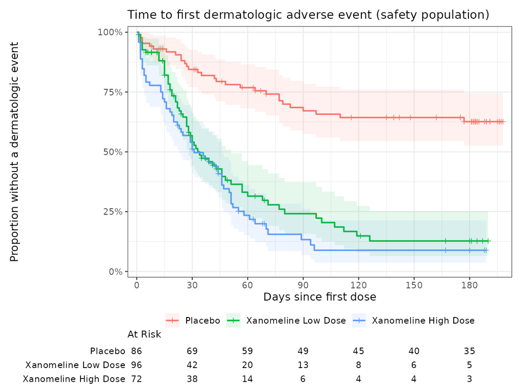

| Arm | Subjects | Events | Median days (95% CI) |
| --- | --- | --- | --- |
| Placebo | 86 | 29 | not reached (not reached, not reached) |
| Xanomeline Low Dose | 96 | 63 | 34 (28, 51) |
| Xanomeline High Dose | 72 | 60 | 31 (23, 46) |

| Term | HR | 95% CI | p |
| --- | --- | --- | --- |
| Xanomeline Low Dose vs placebo | 4.37 | 2.77 - 6.89 | <0.001 |
| Xanomeline High Dose vs placebo | 5.28 | 3.33 - 8.36 | <0.001 |
| Age (per year) | 0.99 | 0.97 - 1.00 | 0.123 |
| Male vs female | 1.46 | 1.06 - 2.02 | 0.022 |

Proportional-hazards check (Schoenfeld residuals): global p = 0.72, so the Cox model assumption holds.

## Adverse events

```
Table 14-5.02 Incidence of Treatment-Emergent Adverse Events by SOC and PT
Population: Safety

-----------------------------------------------------------------------------------------------------------------------------
System organ class                                                     Placebo     Xanomeline Low Dose   Xanomeline High Dose
  Preferred term                                                        (N=86)           (N=96)                 (N=72)
-----------------------------------------------------------------------------------------------------------------------------
Subjects with at least one TEAE                                       65 (75.6%)       84 (87.5%)             69 (95.8%)
Total number of TEAEs                                                    281               427                   418
GENERAL DISORDERS AND ADMINISTRATION SITE CONDITIONS
  Subjects with at least one event                                    21 (24.4%)       51 (53.1%)             36 (50.0%)
  APPLICATION SITE PRURITUS                                            6 (7.0%)        23 (24.0%)             21 (29.2%)
  APPLICATION SITE ERYTHEMA                                            3 (3.5%)        13 (13.5%)             14 (19.4%)
  APPLICATION SITE DERMATITIS                                          5 (5.8%)         9 (9.4%)               7 (9.7%)
  APPLICATION SITE IRRITATION                                          3 (3.5%)         9 (9.4%)              9 (12.5%)
  APPLICATION SITE VESICLES                                            1 (1.2%)         5 (5.2%)               5 (6.9%)
  FATIGUE                                                              1 (1.2%)         5 (5.2%)               5 (6.9%)
  OEDEMA PERIPHERAL                                                    2 (2.3%)         1 (1.0%)               2 (2.8%)
  APPLICATION SITE SWELLING                                               0             1 (1.0%)               2 (2.8%)
  APPLICATION SITE URTICARIA                                              0             2 (2.1%)               1 (1.4%)
  CHILLS                                                               1 (1.2%)         1 (1.0%)               1 (1.4%)
  MALAISE                                                                 0             1 (1.0%)               2 (2.8%)
  PYREXIA                                                              2 (2.3%)         1 (1.0%)                  0
  APPLICATION SITE PAIN                                                   0                 0                  2 (2.8%)
  APPLICATION SITE PERSPIRATION                                           0                 0                  2 (2.8%)
  APPLICATION SITE REACTION                                            1 (1.2%)             0                  1 (1.4%)
  ASTHENIA                                                             1 (1.2%)         1 (1.0%)                  0
  CHEST DISCOMFORT                                                        0             1 (1.0%)               1 (1.4%)
  CHEST PAIN                                                              0                 0                  2 (2.8%)
  OEDEMA                                                                  0             2 (2.1%)                  0
  PAIN                                                                    0             1 (1.0%)               1 (1.4%)
  APPLICATION SITE BLEEDING                                               0             1 (1.0%)                  0
  APPLICATION SITE DESQUAMATION                                           0             1 (1.0%)                  0
  APPLICATION SITE DISCHARGE                                              0                 0                  1 (1.4%)
  APPLICATION SITE DISCOLOURATION                                         0             1 (1.0%)                  0
  APPLICATION SITE INDURATION                                          1 (1.2%)             0                     0
  APPLICATION SITE WARMTH                                                 0             1 (1.0%)                  0
  FEELING ABNORMAL                                                        0                 0                  1 (1.4%)
  FEELING COLD                                                            0                 0                  1 (1.4%)
  INFLAMMATION                                                            0             1 (1.0%)                  0
```

First 40 lines shown; the full table is in `outputs/t_14_5_02_teae_soc_pt.txt`.